# Simplex_IC_non parametrique

jbw

2024-08-12

Loading of the data

```r
### reouverture fichier
library(tidyverse)
library(viridis)
final_data <- read_csv("final_file_all_test_patient120824.csv", na = c("", "NA", -100))
```

```
## ──────────────────────────────────────────────────────── Delimiter: "," chr
## (1): number dbl (18): ...1, weight, living, CNI, MMF_MPS, MTOR, AZA, rec_prot,
## SRD, don_...
```

```r
combined_data2 <-read_csv("combined_data_epalin_data120824.csv", na = c("", "NA", -100)) %>% arrange(don_age)
```

```
## ──────────────────────────────────────────────────────── Delimiter: "," chr
## (1): number dbl (17): ...1, living, CNI, MMF_MPS, MTOR, AZA, rec_prot, SRD,
## don_age, rec...
```

# # Distribution of the simplex corpus

Histogram plot

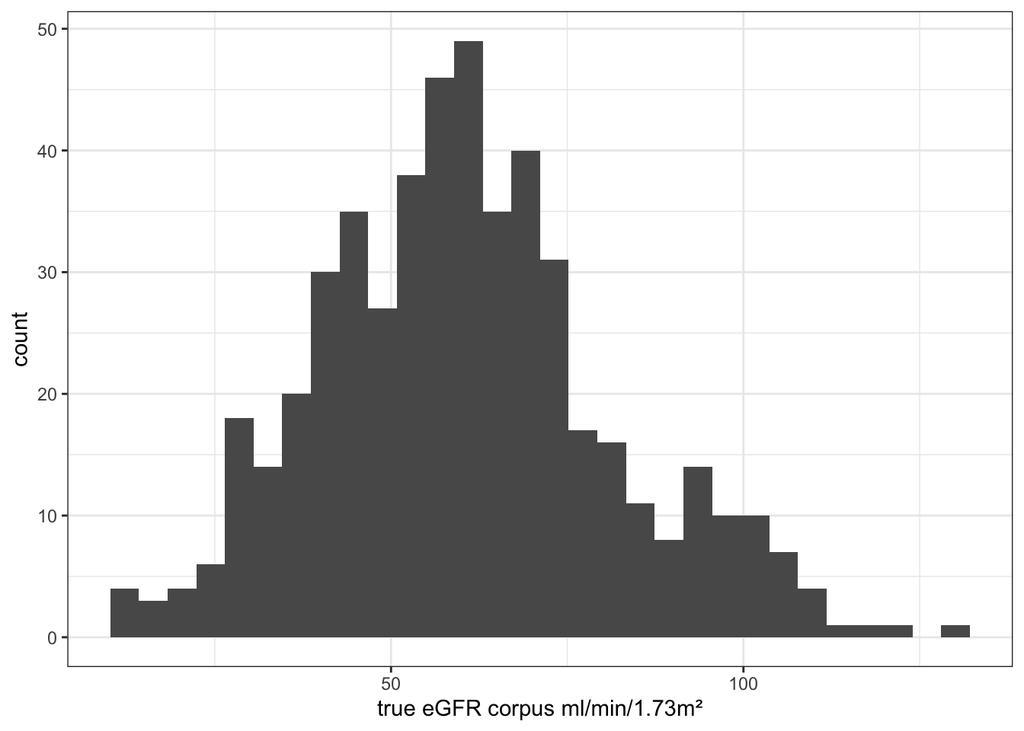

```r
# dsitribution histogramme simplex
final_data %>% filter(number=='000') %>% ggplot(aes(x = true_eGFR)) +
  geom_histogram() +
  theme_bw() + labs(x = "true eGFR corpus ml/min/1.73m²")
```

```r
ggsave("Figure2_hist_egfr_corpus_simplex.pdf")
```

### Statistical Description of the SimplEx Corpus for Table 1

```r
# Step 1: Filter the final data to include only records where 'number' equals '000'
# and create a new corpus dataset. The CNI and SRD variables are transformed into
# binary variables (1 if greater than 0, otherwise 0).

corpus_examples <- final_data %>%
  filter(number == '000') %>%        # Filter for rows where 'number' is '000'
  mutate(
    CNI = if_else(CNI > 0, 1, 0),    # Convert CNI to binary (1 if > 0, else 0)
    SRD = if_else(SRD > 0, 1, 0)     # Convert SRD to binary (1 if > 0, else 0)
  )

# Step 2: Calculate the interquartile range (IQR) for the true eGFR values within the filtered corpus.
# The summary includes the 0th (min), 25th, 50th (median), 75th, and 100th (max) percentiles.

final_data %>%
  filter(number == '000') %>%        # Filter for rows where 'number' is '000'
  summarise(
    quantile_true_eGFR_corpus = quantile(true_eGFR, c(0, 0.25, 0.5, 0.75, 1)),  # Calculate the quantiles (IQR)
    q = c(0, 0.25, 0.5, 0.75, 1),    # Specify the quantiles for reference
    n = n()                          # Count the number of observations in the corpus
  )
```

```
## # A tibble: 5 × 3
##   quantile_true_eGFR_corpus     q     n
##                       <dbl> <dbl> <int>
## 1                      11.0  0      501
## 2                      45.8  0.25   501
## 3                      59.3  0.5    501
## 4                      72.0  0.75   501
## 5                     129.   1      501
```

## Tableone corpus

```r
#recuperation des noms
# dput(names((corpus_examples)))
library(tableone)
## Vector of categorical variables that need transformation
catVars <- c("living","CNI", "MMF_MPS", "MTOR", "AZA",  "SRD",  "ARE01")
## Create a variable list.
vars <- c("living","CNI", "MMF_MPS", "MTOR", "AZA", "rec_prot", "SRD", "don_age",
          "rec_age", "CIT", "PRA1", "PRA2", "RANK", "ARE01", "true_eGFR",
          "hat_eGFR")
tableOne <- CreateTableOne(vars = vars, factorVars = catVars, data = corpus_examples)
tableOne2<-print(tableOne, nonnormal = c("rec_prot",  "don_age","rec_age", "CIT", "PRA1", "PRA2", "RANK", "true_eGFR", "hat_eGFR"), printToggle=F, minMax=T)
tableOne2b<-print(tableOne, nonnormal = c("rec_prot",  "don_age","rec_age", "CIT", "PRA1", "PRA2", "RANK", "true_eGFR", "hat_eGFR"), printToggle=F, minMax=F)

kableone(tableOne2)
```

|  | Overall |
| --- | --- |
| n | 501 |
| living = 1 (%) | 178 ( 35.5) |
| CNI = 1 (%) | 501 (100.0) |
| MMF_MPS = 1 (%) | 191 ( 38.1) |
| MTOR = 1 (%) | 4 ( 0.8) |
| AZA = 1 (%) | 2 ( 0.4) |
| rec_prot (median [range]) | 0.12 [0.03, 17.00] |
| SRD = 1 (%) | 501 (100.0) |
| don_age (median [range]) | 51.00 [4.00, 85.00] |
| rec_age (median [range]) | 53.00 [18.00, 82.00] |
| CIT (median [range]) | 630.00 [44.00, 1738.00] |
| PRA1 (median [range]) | 0.00 [0.00, 1.00] |
| PRA2 (median [range]) | 0.00 [0.00, 1.00] |
| RANK (median [range]) | 1.00 [1.00, 5.00] |
| ARE01 = 1 (%) | 34 ( 6.8) |
| true_eGFR (median [range]) | 59.27 [10.99, 128.89] |
| hat_eGFR (median [range]) | 59.87 [13.05, 103.98] |

```r
kableone(tableOne2b)
```

|  | Overall |
| --- | --- |
| n | 501 |
| living = 1 (%) | 178 ( 35.5) |
| CNI = 1 (%) | 501 (100.0) |
| MMF_MPS = 1 (%) | 191 ( 38.1) |
| MTOR = 1 (%) | 4 ( 0.8) |
| AZA = 1 (%) | 2 ( 0.4) |
| rec_prot (median [IQR]) | 0.12 [0.07, 0.27] |
| SRD = 1 (%) | 501 (100.0) |
| don_age (median [IQR]) | 51.00 [39.00, 61.00] |
| rec_age (median [IQR]) | 53.00 [40.00, 63.00] |
| CIT (median [IQR]) | 630.00 [234.00, 903.00] |
| PRA1 (median [IQR]) | 0.00 [0.00, 0.00] |
| PRA2 (median [IQR]) | 0.00 [0.00, 0.00] |
| RANK (median [IQR]) | 1.00 [1.00, 1.00] |
| ARE01 = 1 (%) | 34 ( 6.8) |
| true_eGFR (median [IQR]) | 59.27 [45.82, 71.95] |
| hat_eGFR (median [IQR]) | 59.87 [45.91, 72.07] |

## Weighted quantiles

```r
## Weighted Quantiles Calculation

# Load the necessary library for weighted quantiles
library(reldist)
# Step 1: Group the final data by 'number' and filter the dataset to include only records
# where the 'weight' is greater than 2.5% (0.025).
final_quant_res <- final_data %>%
  group_by(number) %>%                    # Group data by 'number'

  # Filter for records with 'weight' greater than 0.025 (2.5%)
  filter(weight > 0.025) %>%

  # Step 2: Calculate weighted quantiles for the 'true_eGFR' variable.
  # The quantiles are calculated at 0%, 5%, 25%, 50%, 75%, 95%, and 100% levels.
  reframe(
    wquant_true_egfr = wtd.quantile(
      x = true_eGFR,                      # The variable for which quantiles are calculated
      q = c(0, 0.05, 0.25, 0.5, 0.75, 0.95, 1),  # Quantile levels
      na.rm = TRUE,                       # Remove missing values before calculating
      weight = weight                     # Use 'weight' as the weighting variable
    ),
    n = n()                               # Count the number of observations
  ) %>%

  # Step 3: Add a column for the quantile levels for easier reference
  mutate(
    quant = rep(c(0, 0.05, 0.25, 0.5, 0.75, 0.95, 1), times = 400)  # Repeat quantile levels
  ) %>%

  # Step 4: Merge the quantile results with another dataset (combined_data2)
  # This join adds additional columns from 'combined_data2' to the quantile results
  left_join(combined_data2) %>%

  # Step 5: Select and organize the relevant columns for the final output
  select(
    number,                               # Retain the 'number' column
    wquant_true_egfr,                     # Retain the calculated weighted quantiles
    quant,                                # Retain the quantile levels
    hat_eGFR,                             # Predicted eGFR values
    true_eGFR,                            # Actual true eGFR values
    n                                     # Number of observations
  ) %>%

  # Step 6: Reshape the data from long to wide format so that each quantile level becomes
  # a separate column with the corresponding weighted quantile values.
  pivot_wider(
    names_from = quant,                   # Use quantile levels as the names of new columns
    names_prefix = "quant",               # Prefix these new columns with "quant"
    values_from = wquant_true_egfr        # Populate these columns with the weighted quantile values
  )
```

```r
# number_ex <- final_quant_res %>% filter(between(true_eGFR,21, 25))

# presentaiton of 149 as excmple
final_data %>% filter(number =="149") %>%
  mutate(CNI = if_else(CNI>0,1,0),
         SRD= if_else(SRD>0,1,0)) %>%
  filter(weight>0.025)
```

```
## # A tibble: 4 × 19
##    ...1 number weight living   CNI MMF_MPS  MTOR   AZA rec_prot   SRD don_age
##   <dbl> <chr>   <dbl>  <dbl> <dbl>   <dbl> <dbl> <dbl>    <dbl> <dbl>   <dbl>
## 1 74650 149    0.354       1     1       0     0     0       NA     1      48
## 2 74651 149    0.336       1     1       0     0     0       NA     1      51
## 3 74652 149    0.248       0     1       0     0     0       NA     1      62
## 4 74653 149    0.0327      0     1       0     0     0       NA     1      52
## # ℹ 8 more variables: rec_age <dbl>, CIT <dbl>, PRA1 <dbl>, PRA2 <dbl>,
## #   RANK <dbl>, ARE01 <dbl>, true_eGFR <dbl>, hat_eGFR <dbl>
```

```r
combined_data2 %>% filter(number =="149")
```

```
## # A tibble: 1 × 18
##    ...1 living   CNI MMF_MPS  MTOR   AZA rec_prot   SRD don_age rec_age   CIT
##   <dbl>  <dbl> <dbl>   <dbl> <dbl> <dbl>    <dbl> <dbl>   <dbl>   <dbl> <dbl>
## 1   150      1     1       0     0     0       NA     1      54      28    60
## # ℹ 7 more variables: PRA1 <dbl>, PRA2 <dbl>, RANK <dbl>, ARE01 <dbl>,
## #   true_eGFR <dbl>, hat_eGFR <dbl>, number <chr>
```

## Graphical Representation for All Patients: Simplex Range as a Function of Predicted - True eGFR

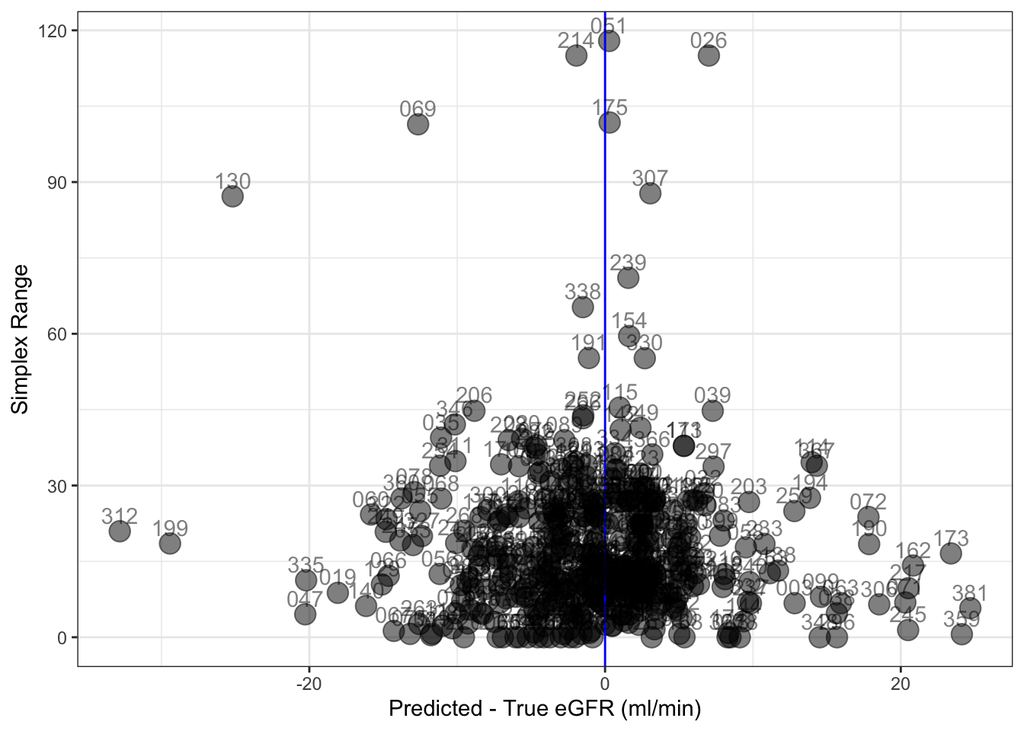

```r
# Load necessary libraries
library(ggplot2)
library(viridis)

# Create a scatter plot using ggplot2
ggplot(
  final_quant_res %>%
    mutate(simplex_range = quant1 - quant0),  # Calculate the Simplex range (difference between 1st and 0th quantiles)
  aes(y = simplex_range, x = hat_eGFR - true_eGFR)  # Map the Simplex range to the y-axis and (pred - true eGFR) to the x-axis
) +
  geom_point(aes(size = 1), alpha = 0.5, show.legend = FALSE) +  # Plot each point with slight transparency and no legend
  # geom_errorbar(                                             # (Optional) Uncomment to add error bars for each point
  #   aes(ymin = quant0 - true_eGFR, ymax = quant1 - true_eGFR), # Define the lower and upper limits of the error bars
  #   width = 0.2,                                              # Set the width of the error bars
  #   alpha = 0.3                                               # Set the transparency of the error bars
  # ) +
  scale_color_viridis() +  # Use the Viridis color scale for a perceptually uniform color scheme
  geom_vline(xintercept = 0, color = "blue") +  # Add a vertical line at x = 0 to indicate where predicted = true eGFR
  theme_bw() +  # Apply a clean black-and-white theme to the plot
  geom_text(
    aes(label = number),  # Annotate each point with its corresponding patient number
    vjust = -0.5,         # Adjust the vertical position of the labels
    hjust = 0.5,          # Adjust the horizontal position of the labels
    alpha = 0.5           # Set the transparency of the labels
  ) +
  labs(
    x = "Predicted - True eGFR (ml/min)",  # Label for the x-axis
    y = "Simplex Range",                   # Label for the y-axis
    size = ""                              # Title for the size aesthetic (left empty as it’s not needed)
  )
```

```r
# Save the plot to a PDF file
ggsave("volcanoplot_simplex_range_vs_pred-true_egfr.pdf")
```

## Graphical Representation: Scatterplot of Residuals vs. True eGFR with Identity Line (Figure 4)

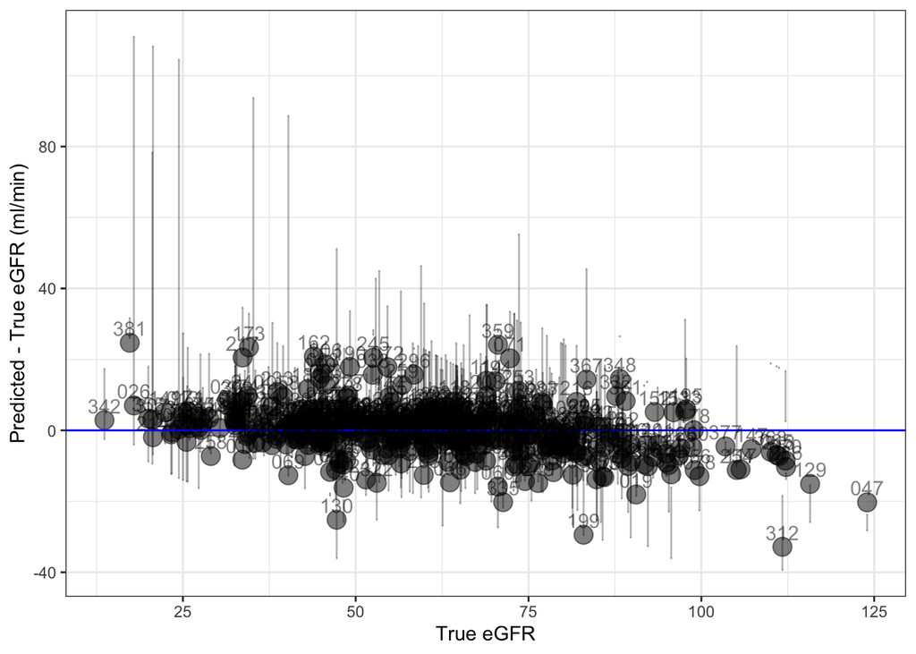

```r
# Create a scatter plot with error bars and an identity line
ggplot(final_quant_res, aes(x = true_eGFR, y = hat_eGFR - true_eGFR)) +
  geom_point(aes(size = 1), alpha = 0.5, show.legend = FALSE) +  # Scatter plot points with slight transparency and no legend

  # Add error bars to represent the range between quant0 and quant1 relative to true eGFR
  geom_errorbar(
    aes(ymin = quant0 - true_eGFR, ymax = quant1 - true_eGFR),  # Error bars based on the Simplex range (quant0 to quant1)
    width = 0.2,            # Set the width of the error bars
    alpha = 0.3             # Set the transparency of the error bars
  ) +

  scale_color_viridis() +   # Use the Viridis color scale for a visually accessible color scheme

  geom_hline(yintercept = 0, color = "blue") +  # Add a horizontal blue line at y = 0 (identity line), where predicted eGFR equals true eGFR

  theme_bw() +              # Apply a clean black-and-white theme to the plot

  # Add patient labels to the points
  geom_text(
    aes(label = number),    # Annotate each point with its corresponding patient number
    vjust = -0.5,           # Adjust the vertical position of the labels
    hjust = 0.5,            # Adjust the horizontal position of the labels
    alpha = 0.5             # Set the transparency of the labels
  ) +

  # Label the axes
  labs(
    y = "Predicted - True eGFR (ml/min)",  # Label for the y-axis
    x = "True eGFR",                       # Label for the x-axis
    size = ""                              # Title for the size aesthetic (left empty as it’s not needed)
  )
```

```r
# Save the plot as a PDF file
ggsave("Figure4_all_patients_corpus_ci_pred-true_vs_true_gfr.pdf")
```

## Calculation of the Number of Patients with Predictions Within the Interval

```r
# Step 1: Create a new column 'pred_interval' that indicates whether the true eGFR
# is within the Simplex range (between quant0 and quant1).
final_quant_res %>%
  mutate(
    pred_interval = if_else(
      between(true_eGFR, quant0, quant1),  # Check if true eGFR is within the range [quant0, quant1]
      1,                                   # If true eGFR is within the interval, set pred_interval to 1
      0                                    # If not, set pred_interval to 0
    )
  ) %>%

  # Step 2: Calculate the proportion of patients whose true eGFR is within the predicted interval
  summarise(
    prop_cible = mean(pred_interval == 1)  # Calculate the mean of 'pred_interval == 1' to get the proportion
  )
```

```
## # A tibble: 1 × 1
##   prop_cible
##        <dbl>
## 1      0.642
```

## Extraction of Patients Outside the Interval to Evaluate Distance to the Nearest Bound (Q0, Q1, Q2, Q3, and Q4)

```r
# Step 1: Identify patients whose true eGFR falls outside the Simplex-predicted interval
distance_simplex_true_patients_out <- final_quant_res %>%
  mutate(
    pred_interval = ifelse(
      between(true_eGFR, quant0, quant1),  # Check if true eGFR is within the range [quant0, quant1]
      1,                                   # If true eGFR is within the interval, set pred_interval to 1
      0                                    # If not, set pred_interval to 0
    )
  ) %>%
  filter(pred_interval == 0) %>%            # Filter to keep only patients whose true eGFR is outside the interval

  # Step 2: Calculate the distance from the true eGFR to the closest boundary of the Simplex interval
  mutate(
    distance_corpus = pmax(
      true_eGFR - quant1,                  # Calculate the distance to the upper bound (quant1)
      quant0 - true_eGFR,                  # Calculate the distance to the lower bound (quant0)
      0                                    # Ensure the distance is non-negative
    )
  )

# Step 3: Compute the distribution of the minimum distance to the Simplex bounds for patients outside the interval
distance_simplex_true_patients_out %>%
  reframe(
    min_distance_quant = quantile(         # Calculate quantiles of the distance to the nearest bound
      distance_corpus,                     # Use the calculated distances from the previous step
      c(0, 0.25, 0.5, 0.75, 1)             # Calculate the 0th, 25th, 50th, 75th, and 100th percentiles
    ),
    q = c(0, 0.25, 0.5, 0.75, 1)           # Specify the corresponding quantiles for reference
  )
```

```
## # A tibble: 5 × 2
##   min_distance_quant     q
##                <dbl> <dbl>
## 1             0.0489  0
## 2             2.29    0.25
## 3             5.76    0.5
## 4            11.3     0.75
## 5            27.8     1
```

Graphical representation only for patients with true eGFR out of simplex: distance to the closest value of simplex min or max as functon of the diff between true and pred eGFR (non presented in the article)

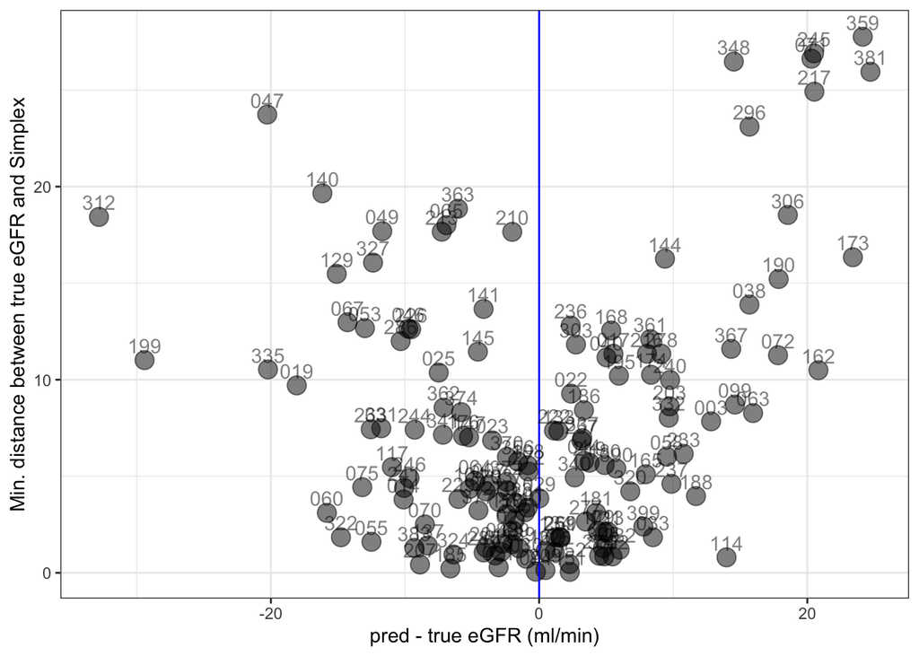

```r
ggplot(distance_simplex_true_patients_out, aes(y = distance_corpus , x = hat_eGFR - true_eGFR)) +
  geom_point(aes(size=1),alpha=0.5, show.legend = FALSE) +  # Scatter plot points
  # geom_errorbar(
  #   aes(ymin = quant0 - true_eGFR , ymax = quant1 - true_eGFR),
  #   width = 0.2,
  #   alpha = 0.3# Adjust the width of the error bars as needed
  #   # position = position_dodge(0.5)  # Adjust the position if needed
  # ) +
  scale_color_viridis() +
  geom_vline(xintercept = 0, color = "blue") +
  theme_bw() +
  geom_text(
    aes(label = number),
    vjust = -0.5,  # Adjust the vertical position of labels
    hjust = 0.5,# Adjust the horizontal position of labels
    alpha = 0.5
  ) +
  labs(x = "pred - true eGFR (ml/min)", y = "Min. distance between true eGFR and Simplex",
       size="")
```

```r
ggsave("patients_out_corpus_distance_simplex_vs_residual.pdf")
```

```r
# ## representaiotn with id as x min max
# # Create the scatter plot with intervals
# set.seed(12345)
# final_quant_res %>%
#   # slice_sample(n=20) %>%
#   ggplot(aes(x = as.numeric(number) , y =  hat_eGFR - true_eGFR, color = true_eGFR )) +
#   geom_point(
#     alpha=0.5,
#     size = 3,
#     show.legend = FALSE) +  # Scatter plot points
#   geom_errorbar(
#     aes(ymin = quant0 - true_eGFR , ymax = quant1- true_eGFR, color = true_eGFR),
#     width = 3,
#     alpha = 0.5# Adjust the width of the error bars as needed
#     # position = position_dodge(0.5)  # Adjust the position if needed
#   ) +
#   scale_color_viridis() +
#   # geom_abline(intercept = 0, slope=1, color = "blue") +
#   theme_bw() +
#   # theme(legend.position="none")+
#   # geom_text(
#   #   aes(label = number),
#   #   vjust = -0.5,  # Adjust the vertical position of labels
#   #   hjust = 0.5,# Adjust the horizontal position of labels
#   #   alpha = 0.4
#   # ) +
#   labs(x = "ID", y = "pred eGFR - true eGFR",
#        color = "true GFR", size="")
#
# ggsave("all_patients_corpus_ci_true_gfr.pdf")
```

## Identify Patients with Poor Prediction (Absolute Difference in GFR > 10) (not presented in the article)

```r
# Step 1: Calculate the absolute difference between predicted and true eGFR for each patient
# Then, arrange the patients in descending order based on this difference and filter to keep
# only those with a difference greater than 10.
bad_predicted_patients <- final_quant_res %>%
  mutate(dif_gfr_abs = abs(hat_eGFR - true_eGFR)) %>%  # Calculate absolute difference between predicted and true eGFR
  arrange(desc(dif_gfr_abs)) %>%                       # Sort patients by the magnitude of the difference
  filter(dif_gfr_abs > 10)                             # Filter to keep patients where the difference is greater than 10
```

## Analyze the Corpus’s Ability to Aid in Understanding Poor Predictions

```r
bad_predicted_patients %>%
  # Optionally exclude patients whose true eGFR is already within the Simplex interval
  # filter(!between(true_eGFR, quant0, quant1)) %>%

  # Step 1: Calculate the distance to the nearest boundary of the Simplex interval for these poorly predicted patients
  mutate(distance_corpus = pmax(true_eGFR - quant1, quant0 - true_eGFR, 0)) %>%

  # Step 2: Calculate quantiles of the minimum distance to the Simplex interval bounds
  reframe(
    min_distance_quant = quantile(distance_corpus, c(0, 0.25, 0.5, 0.75, 1)),  # Quantile distribution of distances
    q = c(0, 0.25, 0.5, 0.75, 1)                                               # Specify quantiles for reference
  )
```

```
## # A tibble: 5 × 2
##   min_distance_quant     q
##                <dbl> <dbl>
## 1               0     0
## 2               0     0.25
## 3               7.85  0.5
## 4              15.5   0.75
## 5              27.8   1
```

## Evaluate whether the corpus brings the prediction closer to the true value

The goal of this analysis is to evaluate whether the Simplex corpus can help improve the accuracy of predictions, specifically by checking if the absolute difference between the lower (or upper) bound of the corpus and the true eGFR is smaller than the absolute difference between the predicted eGFR (hat_eGFR) and the true eGFR (true_eGFR).

```r
bad_predicted_patients %>%
  # Step 1: Calculate the differences between the predicted and true eGFR, as well as between the corpus bounds (quant0, quant1) and the true eGFR
  mutate(
    dif_gfr = hat_eGFR - true_eGFR,            # Calculate the difference between predicted and true eGFR
    dif_quant0_true = quant0 - true_eGFR,      # Calculate the difference between the lower bound (quant0) and true eGFR
    dif_quant1_true = quant1 - true_eGFR       # Calculate the difference between the upper bound (quant1) and true eGFR
  ) %>%

  # Step 2: Determine if the corpus brings the prediction closer to the true value
  # This checks if the difference between the true eGFR and any of the corpus bounds (quant0, quant1)
  # is smaller than the difference between the predicted eGFR and the true eGFR
  mutate(
    corpus_rapporche_pred_0 = case_when(
      abs(dif_quant0_true) < abs(dif_gfr) | abs(dif_quant1_true) < abs(dif_gfr) ~ 1,  # Set to 1 if the corpus improves the prediction
      TRUE ~ 0  # Set to 0 otherwise
    )
  ) %>%

  # Step 3: Summarize the proportion of cases where the corpus improves the prediction accuracy
  summarise(
    raprroche_pred0 = mean(corpus_rapporche_pred_0 == 1),  # Calculate the proportion where the corpus improves accuracy
    somme0 = sum(corpus_rapporche_pred_0),  # Count the total number of cases where the corpus improved the prediction
    n = n()  # Count the total number of observations
  )
```

```
## # A tibble: 1 × 3
##   raprroche_pred0 somme0     n
##             <dbl>  <dbl> <int>
## 1           0.719     41    57
```

plot for these patients

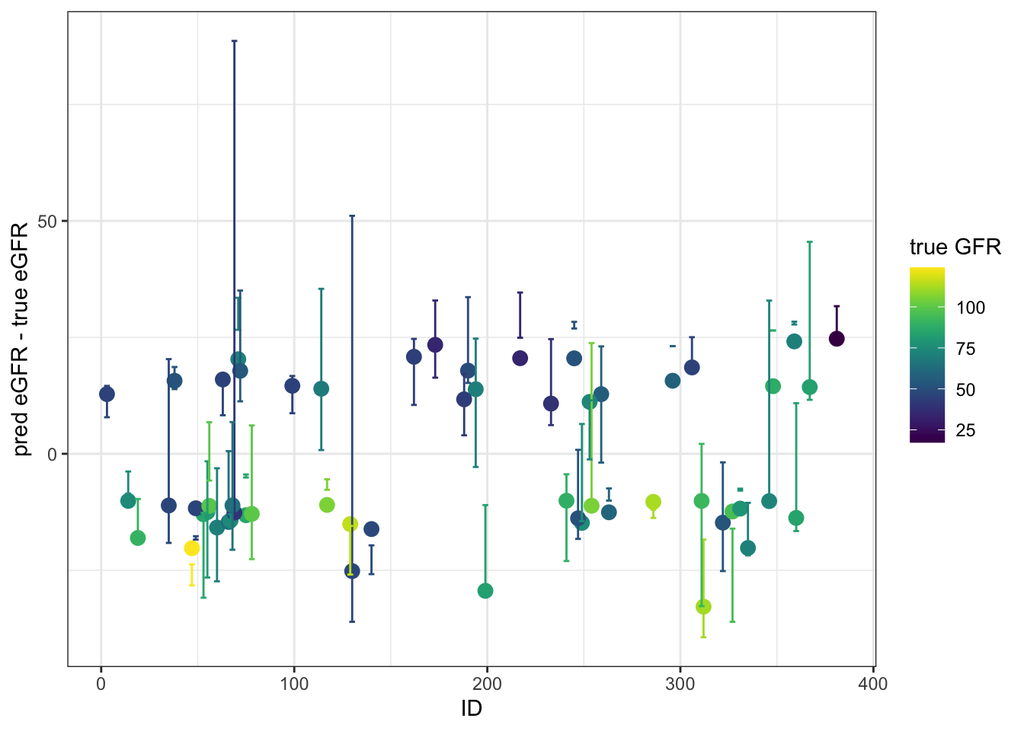

```r
bad_predicted_patients %>%
  ggplot(aes(x = as.numeric(number) , y =  hat_eGFR - true_eGFR, color = true_eGFR )) +
  geom_point(
    # alpha=0.5,
    size = 3,
    show.legend = FALSE) +  # Scatter plot points
  geom_errorbar(
    aes(ymin = quant0 - true_eGFR , ymax = quant1 - true_eGFR, color = true_eGFR),
    width = 3
    # alpha = 0.5# Adjust the width of the error bars as needed
    # position = position_dodge(0.5)  # Adjust the position if needed
  ) +
  scale_color_viridis() +
  # geom_abline(intercept = 0, slope=1, color = "blue") +
  theme_bw() +
  # theme(legend.position="none")+
  # geom_text(
  #   aes(label = number),
  #   vjust = -0.5,  # Adjust the vertical position of labels
  #   hjust = 0.5,# Adjust the horizontal position of labels
  #   alpha = 0.4
  # ) +
  labs(x = "ID", y = "pred eGFR - true eGFR",
       color = "true GFR", size="")
```

```r
ggsave("patients_badly_predicted_lstm_ht10_mlmin.pdf")
```

## Analysis of Patients with GFR < 30 mL/min (Not Presented in Main Article)

```r
# Step 1: Filter patients with true eGFR < 30 mL/min and save the dataset
patient_inf_30 <- final_quant_res %>%
  filter(true_eGFR < 30)  # Filter for patients with true eGFR < 30 mL/min

write.csv(patient_inf_30, file = "patient_inf_30.csv")  # Save the filtered data to a CSV file

# Step 2: Calculate the proportion of patients with true eGFR < 30 mL/min whose values fall within the Simplex-predicted interval
patient_inf_30 %>%
  mutate(
    pred_interval = ifelse(
      between(true_eGFR, quant0, quant1),  # Check if true eGFR is within the Simplex interval [quant0, quant1]
      1,                                   # Set pred_interval to 1 if within the interval
      0                                    # Set pred_interval to 0 if outside the interval
    )
  ) %>%
  summarise(
    prop_cible = mean(pred_interval == 1),  # Proportion of patients with true eGFR within the interval
    n = n()                                 # Total number of patients
  )
```

```
## # A tibble: 1 × 2
##   prop_cible     n
##        <dbl> <int>
## 1      0.864    22
```

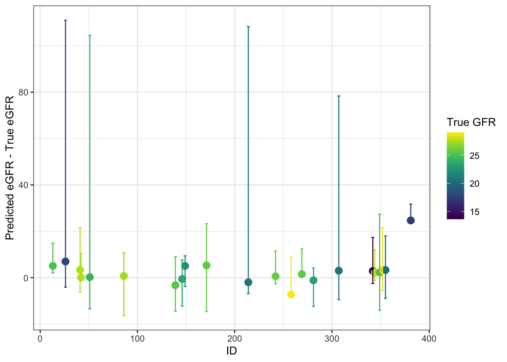

```r
# Step 3: Create a scatter plot showing the prediction error (predicted - true eGFR) for patients with true eGFR < 30 mL/min
patient_inf_30 %>%
  ggplot(aes(x = as.numeric(number), y = hat_eGFR - true_eGFR, color = true_eGFR)) +
  geom_point(size = 3, show.legend = FALSE) +  # Scatter plot points with adjusted size
  geom_errorbar(
    aes(ymin = quant0 - true_eGFR, ymax = quant1 - true_eGFR, color = true_eGFR),  # Error bars representing the Simplex interval
    width = 3
  ) +
  scale_color_viridis() +  # Apply the Viridis color scale
  theme_bw() +  # Apply a clean black-and-white theme
  labs(
    x = "ID", y = "Predicted eGFR - True eGFR",  # Label axes
    color = "True GFR", size = ""
  )
```

```r
ggsave("patients_true_gfr_lt30mlmin.pdf")  # Save the plot as a PDF file
# Step 4: Analyze the distribution of the distance to the Simplex interval bounds for patients with true eGFR < 30 mL/min who are outside the interval
patient_inf_30 %>%
  mutate(
    pred_interval = ifelse(
      between(true_eGFR, quant0, quant1),  # Check if true eGFR is within the Simplex interval [quant0, quant1]
      1,                                   # Set pred_interval to 1 if within the interval
      0                                    # Set pred_interval to 0 if outside the interval
    )
  ) %>%
  filter(pred_interval == 0) %>%  # Filter to keep only patients whose true eGFR is outside the interval
  mutate(
    distance_corpus = pmax(true_eGFR - quant1, quant0 - true_eGFR, 0)  # Calculate distance to the nearest bound of the Simplex interval
  ) %>%
  reframe(
    min_distance_quant = quantile(abs(distance_corpus), c(0, 0.25, 0.5, 0.75, 1)),  # Calculate quantiles of these distances
    q = c(0, 0.25, 0.5, 0.75, 1)  # Specify quantiles for reference
  )
```

```
## # A tibble: 5 × 2
##   min_distance_quant     q
##                <dbl> <dbl>
## 1               1.86  0
## 2               2.00  0.25
## 3               2.14  0.5
## 4              14.0   0.75
## 5              25.9   1
```

### A posteriori evaluation of patients with the steepest slope

A Posteriori Evaluation of Patients with the Steepest Slope This section evaluates patients who experienced the steepest declines in GFR, calculated as the slope between month 12 and month 24 values.

Variation in GFR is calculated as : slope = (month_12 - month_24)/month_24 ) eg if gfr12=60 and gfr24=30, slope = 60-30/30 = 1 A positive slope indicates a steep decline in GFR over 12 months.

```r
## Step 1: Load and clean the slope data
# Load the dataset 'slope_base_valid_120824.csv' which contains slope information for the validation set
library(readr)

slope_base_valid <- read_csv("slope_base_valid_120824.csv",
    col_types = cols(...1 = col_skip())) %>%  # Skip the first unnamed column (not needed)
    distinct(don_age, rec_age, CIT, .keep_all = TRUE)  # Remove duplicate rows based on donor age, recipient age, and CIT
# Step 2: Join slope data with the main dataset
number_slope <- combined_data2 %>%
    left_join(slope_base_valid) %>%  # Join the slope data with the main dataset on matching columns
    select(number, slope)  # Select only the 'number' (patient ID) and 'slope' columns
# Step 3: Check for duplicates in the 'number' column
number_slope$number[duplicated(number_slope$number)]  # Identify any duplicated patient numbers
```

```
## character(0)
```

```r
# Step 4: Identify the top 40 patients with the steepest declines in GFR
first_quartile_patients_highgest_decrease_gfr <- final_quant_res %>%
    left_join(number_slope) %>%  # Merge the slope data with the final results dataset
    arrange(desc(slope)) %>%  # Sort the patients by the steepest slope in descending order
    slice_head(n = 40)  # Select the top 40 patients with the steepest declines
```

## Proportion of Patients with the Steepest Slope Whose True eGFR Falls Within the Simplex Interval

This analysis evaluates how well the Simplex-predicted interval captures the true eGFR values for patients who experienced the steepest declines in kidney function (i.e., those in the first quartile of the steepest slopes).

```r
# Step 1: Identify whether the true eGFR for each patient falls within the Simplex-predicted interval
first_quartile_patients_highgest_decrease_gfr %>%
  mutate(
    pred_interval = ifelse(
      between(true_eGFR, quant0, quant1),  # Check if true eGFR is within the Simplex interval [quant0, quant1]
      1,                                   # Set pred_interval to 1 if within the interval
      0                                    # Set pred_interval to 0 if outside the interval
    )
  ) %>%

  # Step 2: Calculate the proportion of patients whose true eGFR falls within the Simplex interval
  summarise(
    prop_cible = mean(pred_interval == 1),  # Proportion of patients with true eGFR within the interval
    n = n()                                 # Total number of patients evaluated
  )
```

```
## # A tibble: 1 × 2
##   prop_cible     n
##        <dbl> <int>
## 1      0.425    40
```

## Figure 5: Prediction Error vs. True eGFR for Patients with the Steepest Slope

This plot visualizes the prediction error (predicted eGFR - true eGFR) for patients in the first quartile of those with the steepest declines in GFR. It includes error bars representing the Simplex-predicted interval and is presented as Figure 5 in the article.

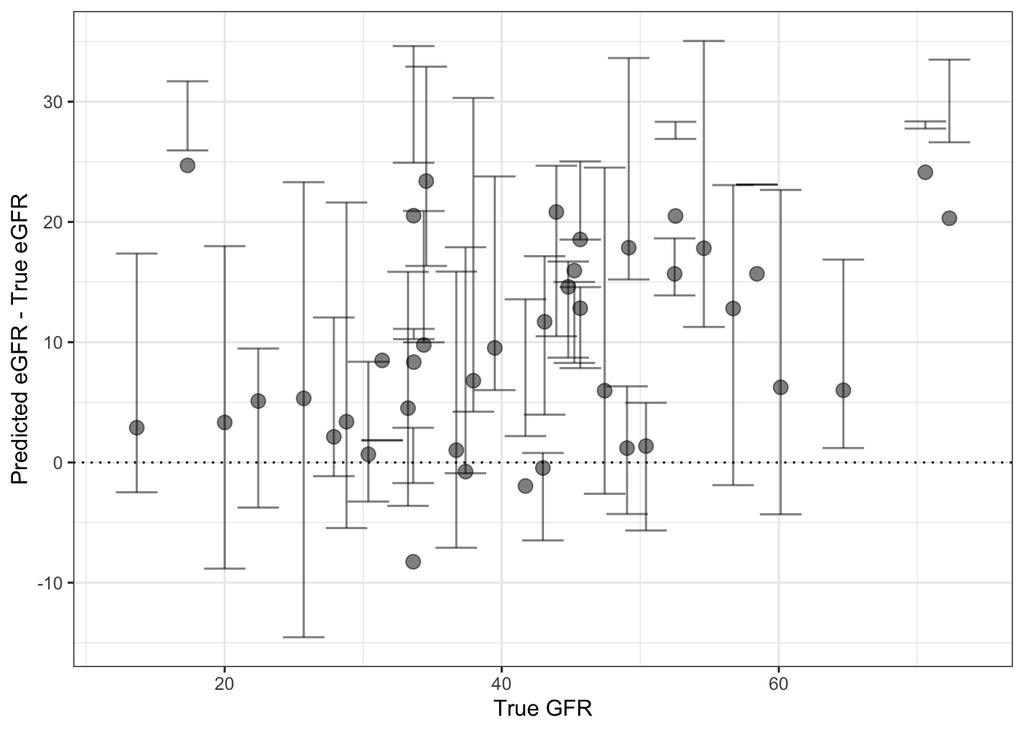

```r
first_quartile_patients_highgest_decrease_gfr %>%
  ggplot(aes(x = true_eGFR, y = hat_eGFR - true_eGFR)) +  # Plot prediction error vs. true eGFR
  geom_point(
    alpha = 0.5,  # Set the transparency of points
    size = 3,     # Set the size of points
    show.legend = FALSE  # Do not show legend
  ) +
  geom_errorbar(
    aes(ymin = quant0 - true_eGFR, ymax = quant1 - true_eGFR),  # Error bars showing Simplex interval
    width = 3,    # Set the width of the error bars
    alpha = 0.5   # Set the transparency of error bars
  ) +
  scale_color_viridis() +  # Apply the Viridis color scale
  geom_hline(yintercept = 0, linetype = 3) +  # Add a horizontal dashed line at y = 0 (zero prediction error)
  theme_bw() +  # Apply a clean black-and-white theme
  labs(
    x = "True GFR",  # Label for the x-axis
    y = "Predicted eGFR - True eGFR",  # Label for the y-axis
    size = ""  # Label for size (not used, so it's left empty)
  )
```

```r
ggsave("Figure5_patients_first_quartile_highest_decrease.pdf")  # Save the plot as a PDF file
```

## Distribution of Distance to Corpus for Patients with the Steepest Slope Not Within the Simplex Interval

This analysis focuses on patients with the steepest declines in GFR (i.e., those in the first quartile of the steepest slopes) whose true eGFR values do not fall within the Simplex-predicted interval. The goal is to examine how far off these values are from the predicted bounds.

```r
# Step 1: Identify whether the true eGFR for each patient falls within the Simplex-predicted interval
first_quartile_patients_highgest_decrease_gfr %>%
  mutate(
    pred_interval = ifelse(
      between(true_eGFR, quant0, quant1),  # Check if true eGFR is within the Simplex interval [quant0, quant1]
      1,                                   # Set pred_interval to 1 if within the interval
      0                                    # Set pred_interval to 0 if outside the interval
    )
  ) %>%

  # Step 2: Filter out patients whose true eGFR falls within the Simplex interval
  filter(pred_interval == 0) %>%  # Keep only those patients whose true eGFR is outside the predicted interval

  # Step 3: Calculate the distance from the true eGFR to the nearest boundary of the Simplex interval
  mutate(
    distance_corpus = pmax(true_eGFR - quant1, quant0 - true_eGFR, 0)  # Compute the distance to the closest interval bound
  ) %>%

  # Step 4: Calculate the quantiles of the distances
  reframe(
    min_distance_quant = quantile(abs(distance_corpus), c(0, 0.25, 0.5, 0.75, 1)),  # Calculate the 0th, 25th, 50th, 75th, and 100th percentiles of the distances
    q = c(0, 0.25, 0.5, 0.75, 1)  # Specify the quantile levels for reference
  )
```

```
## # A tibble: 5 × 2
##   min_distance_quant     q
##                <dbl> <dbl>
## 1               1.20  0
## 2               6.93  0.25
## 3              10.5   0.5
## 4              20.8   0.75
## 5              27.8   1
```

## Analysis of Patients with Prediction Bias Greater Than 10% (Not Presented in Main Article)

This analysis filters out patients from the Simplex corpus who have a prediction bias (predicted eGFR vs. true eGFR) greater than 10%. It then recalculates the weighted quantiles, assesses how many patients have true eGFR within the interval, and evaluates the distance for those outside the interval. Finally, a graphical representation is created for patients whose true eGFR is outside the predicted range.

```r
# Load necessary library for weighted quantiles
library(reldist)

# Step 1: Filter out patients from the corpus with a prediction bias greater than 10%
final_quant_res_filtered <- final_data %>%
  group_by(number) %>%
  # Calculate relative bias between predicted and true eGFR
  mutate(bias_rel = (hat_eGFR - true_eGFR) / true_eGFR) %>%
  # Filter out patients with a bias greater than 10%
  filter(abs(bias_rel) < 0.1) %>%
  # Further filter to include only patients with a weight greater than 1%
  filter(weight > 0.01) %>%
  # Recalculate weighted quantiles for the filtered data
  reframe(
    wquant_true_egfr = wtd.quantile(x = true_eGFR, q = c(0, 0.25, 0.5, 0.75, 1), na.rm = TRUE, weight = weight),
    n = n()
  ) %>%
  # Add quantile labels
  mutate(quant = rep(c(0, 0.25, 0.5, 0.75, 1), times = 390)) %>%
  # Join with additional data from combined_data2
  left_join(combined_data2) %>%
  # Select relevant columns for further analysis
  select(number, wquant_true_egfr, quant, hat_eGFR, true_eGFR, n) %>%
  # Reshape the data from long to wide format based on quantiles
  pivot_wider(names_from = quant, names_prefix = "quant", values_from = wquant_true_egfr)
# Step 2: Calculate the proportion of patients whose true eGFR falls within the recalculated Simplex interval
final_quant_res_filtered %>%
  mutate(pred_interval = ifelse(between(true_eGFR, quant0, quant1), 1, 0)) %>%
  summarise(prop_cible = mean(pred_interval == 1))
```

```
## # A tibble: 1 × 1
##   prop_cible
##        <dbl>
## 1      0.433
```

```r
# Step 3: Extract patients whose true eGFR is outside the recalculated Simplex interval and evaluate distances
distance_simplex_true_patients_out_filtered <- final_quant_res_filtered %>%
  mutate(pred_interval = ifelse(between(true_eGFR, quant0, quant1), 1, 0)) %>%
  filter(pred_interval == 0) %>%
  # Calculate distance to the nearest bound of the Simplex interval
  mutate(
    dif_min = true_eGFR - quant0,
    diff_max = true_eGFR - quant1,
    min_distance = pmin(abs(diff_max), abs(dif_min)),
    dif_median = true_eGFR - quant0.5
  )

# Calculate the distribution of distances to the nearest Simplex interval bound
distance_simplex_true_patients_out_filtered %>%
  reframe(
    min_distance_quant = quantile(min_distance, c(0, 0.25, 0.5, 0.75, 1)),
    q = c(0, 0.25, 0.5, 0.75, 1)
  )
```

```
## # A tibble: 5 × 2
##   min_distance_quant     q
##                <dbl> <dbl>
## 1             0.0489  0
## 2             2.87    0.25
## 3             5.57    0.5
## 4            10.3     0.75
## 5            27.8     1
```

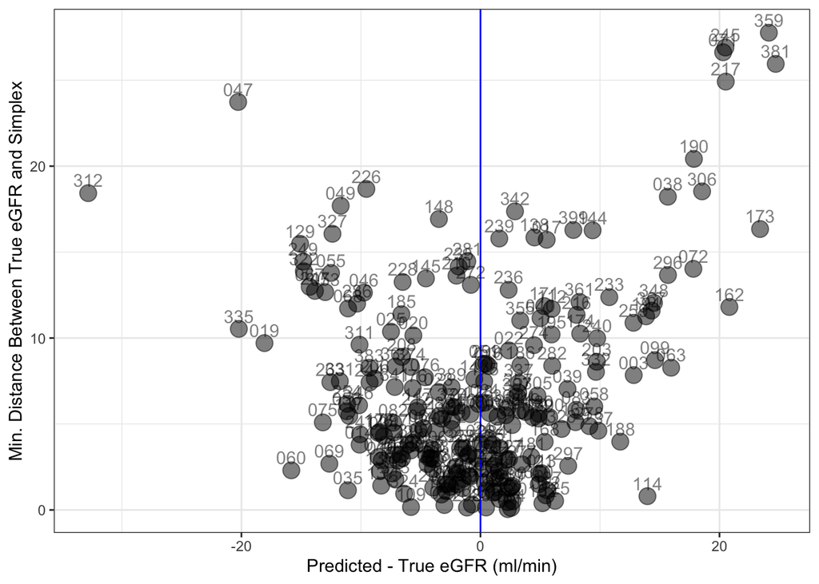

```r
# Step 4: Graphical representation of the distance to the nearest Simplex bound for patients with true eGFR outside the Simplex interval
ggplot(distance_simplex_true_patients_out_filtered, aes(y = min_distance, x = hat_eGFR - true_eGFR)) +
  geom_point(aes(size = 1), alpha = 0.5, show.legend = FALSE) +  # Scatter plot points
  scale_color_viridis() +
  geom_vline(xintercept = 0, color = "blue") +  # Add a vertical line at x = 0 (no prediction error)
  theme_bw() +
  geom_text(
    aes(label = number),
    vjust = -0.5,  # Adjust the vertical position of labels
    hjust = 0.5,   # Adjust the horizontal position of labels
    alpha = 0.5    # Set the transparency of labels
  ) +
  labs(
    x = "Predicted - True eGFR (ml/min)",  # Label for the x-axis
    y = "Min. Distance Between True eGFR and Simplex",  # Label for the y-axis
    size = ""
  )
```

```r
# Save the plot
ggsave("patients_outside_simplex_min_distance_vs_pred_error.pdf")
```